# The Effects of Climate Change on Wildfires and Air Quality

Thanh Ly, Emma O’Dwyer, Jennifer Gomez, Cole Meier

11/13/2022

## Summary Information

With our datasets, we analyzed various areas of interest regarding wildfires and air quality in the United States. From our analysis, we found that the largest fire had affected 606945.00 acres, while the average affected number of acres for fires is 2104.65. We also found that the most common fire size class is “B”, where A is the lowest severity and G is the highest. The most common cause of wildfires is “Debris Burning”, and the most common state for wildfires to occur is “TX”. Due to our studies being in Washington state, we were also interested in information specific to Washington state. We found that in Washington, the mean fire size is 6458.59 acres, the most common fire size class is “B”, and the most common cause of wildfires in Washington is “Lightning”.

For air quality, we found that the max air quality index recorded in the United States is 20646.00, where higher aqi numbers indicate worse air quality. The average air quality in the United States is 46.70, and the most common air quality category is “Good”.

## Aggregate Table

| years | temperature_anomalies | median_aqi | avg_num_fires | mean_size |
| --- | --- | --- | --- | --- |
| 1992 | -1.00 | 37 | 848 | 713 |
| 1993 | -0.55 | 38 | 801 | 550 |
| 1994 | 0.60 | 39 | 714 | 1663 |
| 1995 | 0.58 | 38 | 768 | 530 |
| 1996 | -0.14 | 38 | 908 | 1864 |
| 1997 | 1.26 | 38 | 644 | 1925 |
| 1998 | 1.72 | 40 | 743 | 530 |
| 1999 | 0.39 | 44 | 1034 | 2304 |
| 2000 | 0.22 | 44 | 1219 | 1809 |
| 2001 | 1.13 | 44 | 1031 | 1246 |
| 2002 | 1.01 | 43 | 853 | 1996 |
| 2003 | 0.61 | 43 | 615 | 1340 |
| 2004 | 0.25 | 41 | 697 | 4237 |
| 2005 | 1.17 | 43 | 1117 | 1953 |
| 2006 | 0.58 | 43 | 1665 | 2251 |
| 2007 | 0.59 | 44 | 1169 | 2597 |
| 2008 | 0.36 | 42 | 1080 | 830 |
| 2009 | 1.51 | 40 | 980 | 1942 |
| 2010 | 0.85 | 42 | 915 | 744 |
| 2011 | 1.43 | 43 | 1125 | 3087 |
| 2012 | 1.41 | 42 | 1009 | 4889 |
| 2013 | 1.40 | 41 | 687 | 2202 |
| 2014 | 0.76 | 41 | 673 | 951 |
| 2015 | 1.52 | 42 | 773 | 3154 |

From this table, we see that land temperature in North America has been overall rising. It is a bit difficult to tell if the number of wildfires are definitively increasing or not, but it is clear that size of these fires are growing much larger. Prior to 2011, very few years had a mean_size of 2000 or larger; there are a total of 4 such cases from 1992-2010. However from 2011-2015, 4 out of 5 of those years had a mean_size of 2000 or larger. Despite the mean_size growing larger, there does not seem to be a significant change in the aqi, however the slight increase does indicate that the air quality has gotten slightly worse.

## Charts

### Chart 1: Bar Chart of Mean AQI per Year

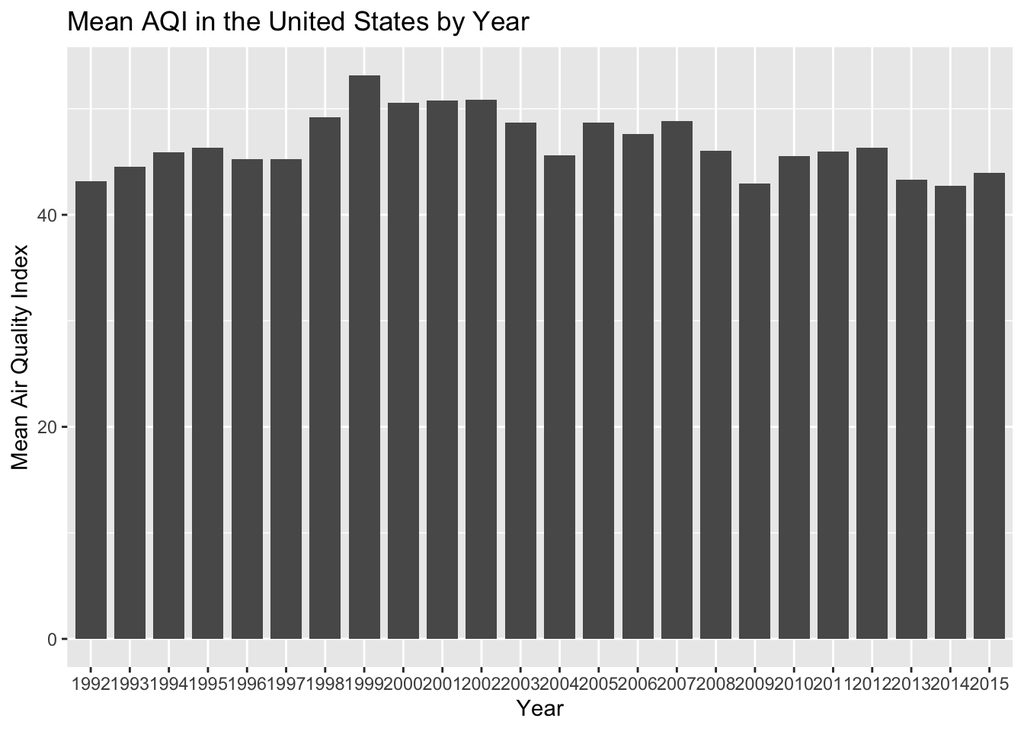

### Chart 2: Pie Chart of the Causes of Wildires in the United States

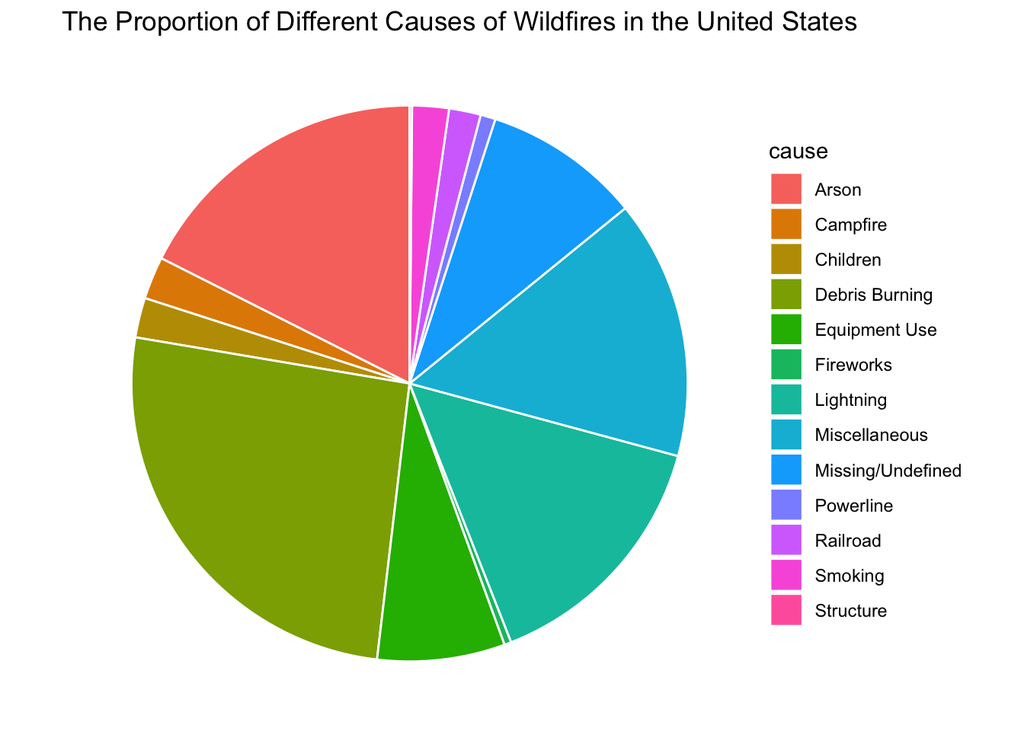

We included this chart because we were interested in what the main causes for wildfires are. It is important to know what the causes are as it can help us tailor solutions to help prevent wildfires being created from those major causes. From this pie chart, we see that debris burning most wildfires are caused by debris burning, followed closely by arson, lightning, and miscellaneous reasons, where all 3 causes are quite close in number.

### Chart 3: Scatterplot of Mean AQI per Year vs. Number of Wildfires per Year

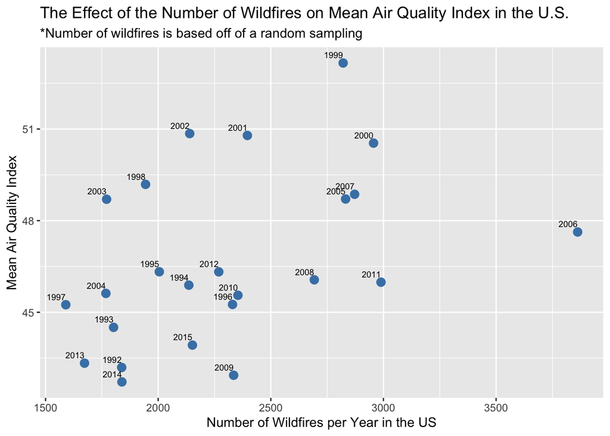

This chart was included because we wanted to see the relationship between the mean air quality index (AQI) per year and the number of wildfires per year as this relationship might reveal if and how much wildfires are affecting the air quality. From this scatterplot, we see that there isn’t exactly a definitive relationship. There seems to be a **very** loose relationship between number of wildfires per year and the mean AQI of that year, where more wildfires means a higher AQI (worse air).